# Reproducible Research: Peer Assessment 1

## Loading and preprocessing the data

We simply load the data in using *read.csv*. We perform no extra processing on the data.

```r
raw.data <- read.csv('data/activity.csv')
```

## What is mean total number of steps taken per day?

We can easily calculate the total number of steps taken per day by grouping the data by the date, and then summing all the steps occuring on that date:

```r
library(dplyr)
total.steps <- raw.data %>% group_by(date) %>% summarise(total = sum(steps))
```

The first few rows of this data looks like this:

```r
knitr::kable(head(total.steps))
```

| date | total |
| --- | --- |
| 2012-10-01 | NA |
| 2012-10-02 | 126 |
| 2012-10-03 | 11352 |
| 2012-10-04 | 12116 |
| 2012-10-05 | 13294 |
| 2012-10-06 | 15420 |

And we can use *ggplot2* to show a histogram of the total number of steps taken.

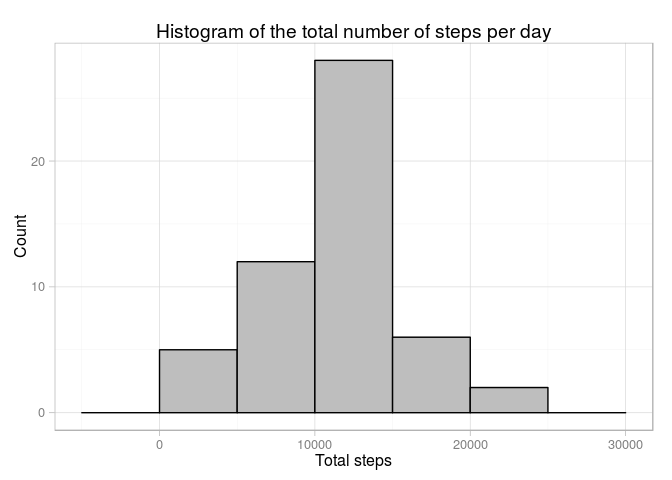

```r
library(ggplot2)

create_histogram <- function(data, title) {
    g <- ggplot(data, aes(x = total))
    g <- g + geom_histogram(binwidth = 5000, fill="grey", colour="black")
    g <- g + labs(title = title,
                  x = "Total steps",
                  y = "Count")
    g <- g + theme_light()
    g
}

create_histogram(total.steps, "Histogram of the total number of steps per day")
```

The mean and median of the total number of steps taken per day can be calculated like so:

```r
summaries <- total.steps %>% summarise(mean = mean(total, na.rm = TRUE),
                                       median = median(total, na.rm = TRUE))
knitr::kable(summaries, digits = 2)
```

| mean | median |
| --- | --- |
| 10766.19 | 10765 |

Notice that both values are very similar to one another.

## What is the average daily activity pattern?

First, we want to calculate the average number of steps taken per interval period, across all days:

```r
interval.means <- raw.data %>%
    group_by(interval) %>%
    summarise(mean = mean(steps, na.rm = TRUE))
```

Then we plot this average as a timeseries line-chart:

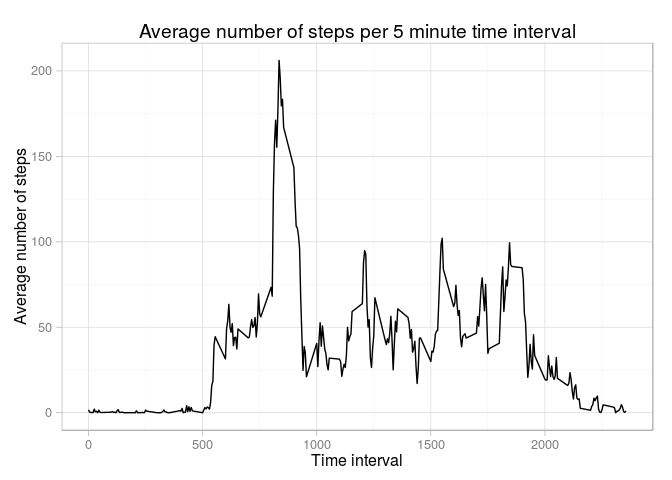

```r
g <- ggplot(interval.means, aes(x = interval, y = mean))
g <- g + geom_line()
g <- g + labs(title = "Average number of steps per 5 minute time interval",
              x = "Time interval",
              y = "Average number of steps")
g <- g + theme_light()
print(g)
```

The interval that has on average the maximum number of steps can be calculated like so:

```r
maximum.interval <- filter(interval.means, mean == max(interval.means$mean))
```

Interval 835 has the maximum mean of 206.17 steps.

## Imputing missing values

The number of rows that contain NA values can be calculated as:

```r
missing <- nrow(filter(raw.data, is.na(steps)))
```

There are 2304 rows with NA values.

We will fill in the missing step data by substituting the mean value for that interval across all days in the data set. These values were already previously calculated above and are stored in the *interval.means* variable.

```r
imputed.data <- raw.data

for (i in seq_len(nrow(raw.data))) {
    # Test if the value is missing
    if (is.na(imputed.data[i,1])) {
        interval <- imputed.data[i,]$interval
        # Replace the NA
        imputed.data[i, 1] <- interval.means[interval.means$interval == interval,]$mean
    }
}
```

Let us again graph the total number of steps per day as a histogram:

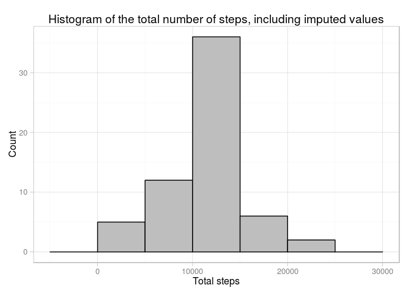

```r
imputed.total.steps <- imputed.data %>% group_by(date) %>% summarise(total = sum(steps))
create_histogram(imputed.total.steps,
                 "Histogram of the total number of steps, including imputed values")
```

And we can calculate the mean and median number of steps taken:

```r
imputed.summaries <- imputed.total.steps %>%
    summarise(mean = mean(total, na.rm = TRUE),
              median = median(total, na.rm = TRUE))
knitr::kable(imputed.summaries, digits = 2)
```

| mean | median |
| --- | --- |
| 10766.19 | 10766.19 |

Mean and median calculated using imputed values are nearly identical to those calculated for the raw data set.

## Are there differences in activity patterns between weekdays and weekends?

For every row of the imputed data set, we add a factor indicating if the day is a week day or not.

```r
imputed.data <- imputed.data %>%
    transform(
        day = factor(ifelse(weekdays(as.POSIXct(date)) %in% c("Saturday", "Sunday"),
                            "WEEKEND", "WEEKDAY"))
    )

knitr::kable(head(imputed.data), digits = 2)
```

| steps | date | interval | day |
| --- | --- | --- | --- |
| 1.72 | 2012-10-01 | 0 | WEEKDAY |
| 0.34 | 2012-10-01 | 5 | WEEKDAY |
| 0.13 | 2012-10-01 | 10 | WEEKDAY |
| 0.15 | 2012-10-01 | 15 | WEEKDAY |
| 0.08 | 2012-10-01 | 20 | WEEKDAY |
| 2.09 | 2012-10-01 | 25 | WEEKDAY |

We then calculate the daily average for each interval for both the week days and weekends.

```r
day.interval.means <- imputed.data %>%
    group_by(day, interval) %>%
    summarise(mean = mean(steps))
```

And now we show a timeseries line-chart of the average time per for weekends vs week days.

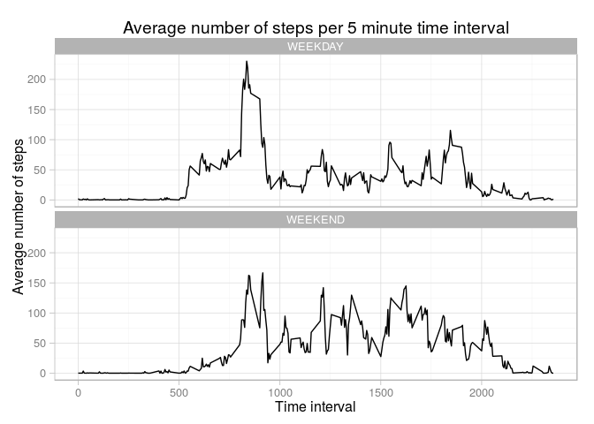

```r
g <- ggplot(day.interval.means, aes(x = interval, y = mean))
g <- g + geom_line()
g <- g + facet_wrap(~ day, nrow = 2)
g <- g + labs(title = "Average number of steps per 5 minute time interval",
              x = "Time interval",
              y = "Average number of steps")
g <- g + theme_light()
print(g)
```